# Lab 4

Christopher Spartz

10/24/2021

```r
library(tidyverse)
```

```r
library(ggplot2)
library(readxl)
defense <- read_excel('cyclonesFootball2020.xlsx', sheet='Defensive')
offense <- read_excel('cyclonesFootball2020.xlsx', sheet='Offensive')
biography <- read_excel('cyclonesFootball2020.xlsx', sheet='Biography')
str(defense)
```

```
## tibble [372 × 11] (S3: tbl_df/tbl/data.frame)
##  $ Name             : chr [1:372] "Rose, Mike" "Rose, Mike" "Rose, Mike" "Rose, Mike" ...
##  $ Opponent_Opponent: chr [1:372] "Louisiana" "TCU" "Oklahoma" "Texas Tech" ...
##  $ Tackles_Solo     : chr [1:372] "2" "6" "6" "3" ...
##  $ Tackles_ASST     : chr [1:372] "4" "4" "5" "0" ...
##  $ Tackles_TFL      : chr [1:372] "1.0" "0" "1.5" "1.0" ...
##  $ Tackles_Sack     : chr [1:372] "0" "0" "0.5" "0" ...
##  $ Turnover_FF      : chr [1:372] "0" "0" "0" "0" ...
##  $ Turnover_FR      : chr [1:372] "0" "0" "0" "0" ...
##  $ Turnover_INT     : chr [1:372] "0" "1" "0" "0" ...
##  $ Pass_QBH         : chr [1:372] "0" "0" "1" "0" ...
##  $ Pass_PB          : chr [1:372] "0" "0" "0" "0" ...
```

```r
str(offense)
```

```
## tibble [156 × 12] (S3: tbl_df/tbl/data.frame)
##  $ Name             : chr [1:156] "Akers, Landen" "Akers, Landen" "Akers, Landen" "Akers, Landen" ...
##  $ Opponent_Opponent: chr [1:156] "Louisiana" "TCU" "Oklahoma" "Texas Tech" ...
##  $ Receiving_REC    : chr [1:156] "0" "2" "1" "4" ...
##  $ Receiving_YDS    : chr [1:156] "0" "60" "35" "34" ...
##  $ Receiving_TD     : chr [1:156] "0" "0" "0" "0" ...
##  $ Rushing_ATT      : chr [1:156] NA NA NA NA ...
##  $ Rushing_YDS      : chr [1:156] NA NA NA NA ...
##  $ Rushing_TD       : chr [1:156] NA NA NA NA ...
##  $ Passing_CMP-ATT  : chr [1:156] NA NA NA NA ...
##  $ Passing_YDS      : chr [1:156] NA NA NA NA ...
##  $ Passing_TD       : chr [1:156] NA NA NA NA ...
##  $ Passing_INT      : chr [1:156] NA NA NA NA ...
```

```r
str(biography)
```

```
## tibble [116 × 7] (S3: tbl_df/tbl/data.frame)
##  $ Name      : chr [1:116] "Akers, Landen" "Allen, Chase" "Anderson, Ezeriah" "Antoine Jr. , Michal" ...
##  $ Position  : chr [1:116] "Wide Receiver" "Tight End" "Wide Receiver" "Defensive Back" ...
##  $ Height    : chr [1:116] "6-0" "6-7" "6-5" "6-0" ...
##  $ Weight    : chr [1:116] "191" "240" "208" "180" ...
##  $ Class     : chr [1:116] "Redshirt Senior" "Redshirt Senior" "Redshirt Freshman" "Freshman" ...
##  $ Hometown  : chr [1:116] "Cedar Rapids, Iowa" "Nixa, Mo." "Seffner, Fla." "Ft. Lauderdale, Fla." ...
##  $ Highschool: chr [1:116] "Washington" "Nixa" "Armwood" "Cardinal Gibbons" ...
```

## 1.

```r
defense$Name <- as.factor(defense$Name)
offense$Name <- as.factor(offense$Name)
defense$Opponent_Opponent <- as.factor(defense$Opponent_Opponent)
offense$Opponent_Opponent <- as.factor(offense$Opponent_Opponent)
```

## 2.

```r
defClean <- defense %>% mutate(across(where(is.character), as.numeric))
offClean <- offense %>% mutate(across(where(is.character), as.numeric))
```

```r
biography$Weight <- as.numeric(biography$Weight)
```

## 3.

```r
bioClean <- biography %>% separate(Height, c('feet', 'inches'), "-", convert = TRUE)
```

## 4.

```r
offClean <- offClean %>% group_by(Name, Opponent_Opponent) %>% mutate(gameNum = row_number()) %>% ungroup()
defClean <- defClean %>% group_by(Name, Opponent_Opponent) %>% mutate(gameNum = row_number()) %>% ungroup()
str(offClean)
```

```
## tibble [156 × 13] (S3: tbl_df/tbl/data.frame)
##  $ Name             : Factor w/ 16 levels "Akers, Landen",..: 1 1 1 1 1 1 1 1 1 1 ...
##  $ Opponent_Opponent: Factor w/ 11 levels "Baylor","Kansas",..: 4 8 5 10 6 2 1 3 9 11 ...
##  $ Receiving_REC    : num [1:156] 0 2 1 4 0 6 1 0 1 1 ...
##  $ Receiving_YDS    : num [1:156] 0 60 35 34 0 76 11 0 10 2 ...
##  $ Receiving_TD     : num [1:156] 0 0 0 0 0 0 0 0 0 1 ...
##  $ Rushing_ATT      : num [1:156] NA NA NA NA NA NA NA NA NA NA ...
##  $ Rushing_YDS      : num [1:156] NA NA NA NA NA NA NA NA NA NA ...
##  $ Rushing_TD       : num [1:156] NA NA NA NA NA NA NA NA NA NA ...
##  $ Passing_CMP-ATT  : num [1:156] NA NA NA NA NA NA NA NA NA NA ...
##  $ Passing_YDS      : num [1:156] NA NA NA NA NA NA NA NA NA NA ...
##  $ Passing_TD       : num [1:156] NA NA NA NA NA NA NA NA NA NA ...
##  $ Passing_INT      : num [1:156] NA NA NA NA NA NA NA NA NA NA ...
##  $ gameNum          : int [1:156] 1 1 1 1 1 1 1 1 1 1 ...
```

```r
str(defClean)
```

```
## tibble [372 × 12] (S3: tbl_df/tbl/data.frame)
##  $ Name             : Factor w/ 37 levels "Akers, Landen",..: 26 26 26 26 26 26 26 26 26 26 ...
##  $ Opponent_Opponent: Factor w/ 11 levels "Baylor","Kansas",..: 4 8 5 10 6 2 1 3 9 11 ...
##  $ Tackles_Solo     : num [1:372] 2 6 6 3 7 4 7 4 4 2 ...
##  $ Tackles_ASST     : num [1:372] 4 4 5 0 3 1 4 3 9 3 ...
##  $ Tackles_TFL      : num [1:372] 1 0 1.5 1 1 0 1.5 2.5 1.5 0 ...
##  $ Tackles_Sack     : num [1:372] 0 0 0.5 0 0 0 0 1 0 0 ...
##  $ Turnover_FF      : num [1:372] 0 0 0 0 0 0 0 0 0 0 ...
##  $ Turnover_FR      : num [1:372] 0 0 0 0 0 0 0 0 0 0 ...
##  $ Turnover_INT     : num [1:372] 0 1 0 0 1 0 1 1 0 0 ...
##  $ Pass_QBH         : num [1:372] 0 0 1 0 0 0 2 1 0 0 ...
##  $ Pass_PB          : num [1:372] 0 0 0 0 0 1 0 0 1 0 ...
##  $ gameNum          : int [1:372] 1 1 1 1 1 1 1 1 1 1 ...
```

```r
str(bioClean)
```

```
## tibble [116 × 8] (S3: tbl_df/tbl/data.frame)
##  $ Name      : chr [1:116] "Akers, Landen" "Allen, Chase" "Anderson, Ezeriah" "Antoine Jr. , Michal" ...
##  $ Position  : chr [1:116] "Wide Receiver" "Tight End" "Wide Receiver" "Defensive Back" ...
##  $ feet      : int [1:116] 6 6 6 6 6 6 6 6 6 6 ...
##  $ inches    : int [1:116] 0 7 5 0 0 0 3 2 2 2 ...
##  $ Weight    : num [1:116] 191 240 208 180 195 199 253 261 288 182 ...
##  $ Class     : chr [1:116] "Redshirt Senior" "Redshirt Senior" "Redshirt Freshman" "Freshman" ...
##  $ Hometown  : chr [1:116] "Cedar Rapids, Iowa" "Nixa, Mo." "Seffner, Fla." "Ft. Lauderdale, Fla." ...
##  $ Highschool: chr [1:116] "Washington" "Nixa" "Armwood" "Cardinal Gibbons" ...
```

## 1.

```r
offCleanStat <- offClean %>% pivot_longer(
  !c('Name','Opponent_Opponent','gameNum'),
  names_to="stat",
  values_to="count",
  values_drop_na = TRUE
)

offCleanStat
```

```
## # A tibble: 648 × 5
##    Name          Opponent_Opponent gameNum stat          count
##    <fct>         <fct>               <int> <chr>         <dbl>
##  1 Akers, Landen Louisiana               1 Receiving_REC     0
##  2 Akers, Landen Louisiana               1 Receiving_YDS     0
##  3 Akers, Landen Louisiana               1 Receiving_TD      0
##  4 Akers, Landen TCU                     1 Receiving_REC     2
##  5 Akers, Landen TCU                     1 Receiving_YDS    60
##  6 Akers, Landen TCU                     1 Receiving_TD      0
##  7 Akers, Landen Oklahoma                1 Receiving_REC     1
##  8 Akers, Landen Oklahoma                1 Receiving_YDS    35
##  9 Akers, Landen Oklahoma                1 Receiving_TD      0
## 10 Akers, Landen Texas Tech              1 Receiving_REC     4
## # … with 638 more rows
```

## 2.

```r
yearStat <- offCleanStat %>% group_by(Name,stat) %>% summarise(overall = sum(count))
```

## 3.

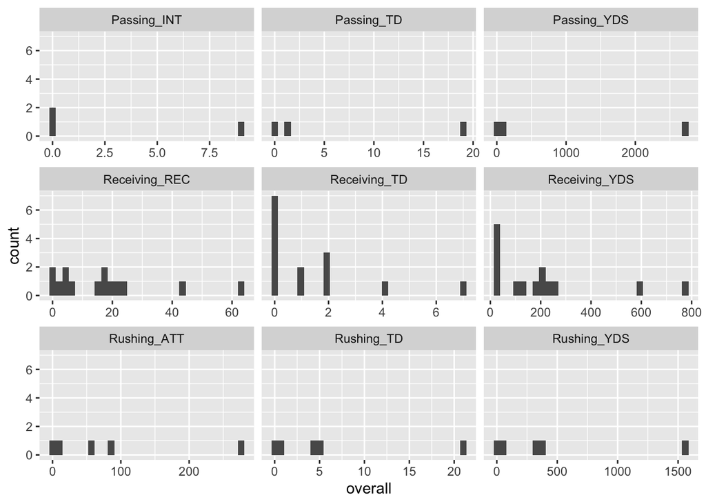

```r
ggplot(aes(x = overall), data=yearStat) + geom_histogram(bins = 30) + facet_wrap(~stat, scales = "free_x")
```

## 4.

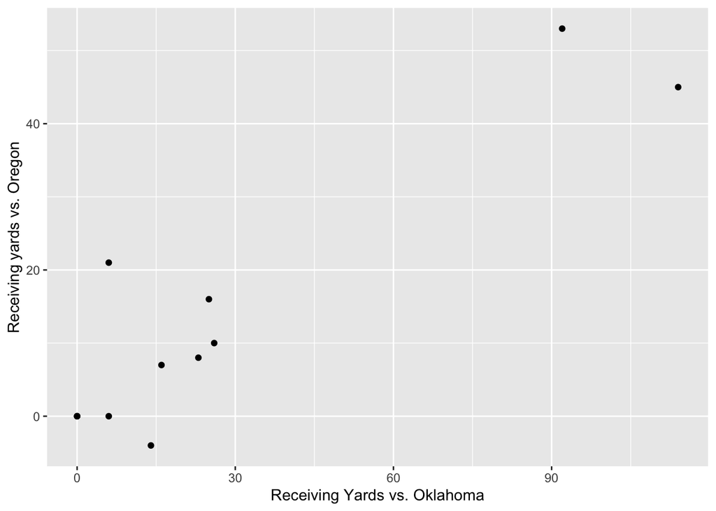

```r
oVo <- offCleanStat %>% group_by(Opponent_Opponent) %>%
  filter(stat=="Receiving_YDS", (Opponent_Opponent=="Oklahoma" & gameNum==2) | Opponent_Opponent=="Oregon") %>%
  select(Opponent_Opponent,count, Name)
oVo <- oVo %>% pivot_wider(names_from = Opponent_Opponent,values_from = count)
oVo %>% ggplot(aes(x=Oklahoma, y=Oregon))+geom_point() + xlab("Receiving Yards vs. Oklahoma") + ylab("Receiving yards vs. Oregon")
```

ISU had a better offense vs. Oklahoma compared to Oregon. More players got more yards playing against Oklahoma compared to against Oregon.

## 5.

```r
bioClean <- bioClean %>% separate(Hometown, c('homeCity', 'homeState'), ",")
```

## 6.

```r
bioClean %>% count(homeState)
```

```
## # A tibble: 21 × 2
##    homeState        n
##    <chr>        <int>
##  1 " Ariz."         4
##  2 " Ark."          1
##  3 " Australia"     1
##  4 " Calif."        2
##  5 " Fla."         14
##  6 " Ga."           3
##  7 " Ill."          6
##  8 " Iowa"         42
##  9 " Kan."          4
## 10 " Mich"          1
## # … with 11 more rows
```

## 7.

```r
purdy <- offClean %>% filter(Name=="Purdy, Brock") %>% select(Rushing_YDS,Passing_YDS,Opponent_Opponent,gameNum)

teamRec <- offCleanStat %>% filter(stat=="Receiving_YDS") %>% group_by(Opponent_Opponent,gameNum) %>%
  summarise(teamreceiving=sum(count))
teamRus <- offCleanStat %>% filter(stat=="Rushing_YDS") %>% group_by(Opponent_Opponent,gameNum) %>%
  summarise(teamrushing=sum(count))
teamTack <- defClean %>% group_by(Opponent_Opponent,gameNum) %>% summarise(teamtackles=sum(Tackles_Solo))
teamSack <- defClean %>% group_by(Opponent_Opponent,gameNum) %>% summarise(teamsacks=sum(Tackles_Sack))
purdyVteam <- purdy %>% inner_join(teamRec, by = c("Opponent_Opponent","gameNum")) %>%
  inner_join(teamRus, by = c("Opponent_Opponent","gameNum")) %>%
  inner_join(teamTack, by = c("Opponent_Opponent","gameNum")) %>%
  inner_join(teamSack, by = c("Opponent_Opponent","gameNum"))
purdyVteam
```

```
## # A tibble: 12 × 8
##    Rushing_YDS Passing_YDS Opponent_Opponent gameNum teamreceiving teamrushing
##          <dbl>       <dbl> <fct>               <int>         <dbl>       <dbl>
##  1          35         145 Louisiana               1           145         159
##  2           6         211 TCU                     1           194         209
##  3          -2         254 Oklahoma                1           282         137
##  4          42         302 Texas Tech              1           292         216
##  5          38         162 Oklahoma St.            1           162         227
##  6          20         239 Kansas                  1           293         262
##  7          55         164 Baylor                  1           146         199
##  8          59         236 Kansas State            1           299         240
##  9          19         312 Texas                   1           307         121
## 10          38         247 West Virginia           1           247         238
## 11          33         322 Oklahoma                2           322         113
## 12          39         156 Oregon                  1           156         230
## # … with 2 more variables: teamtackles <dbl>, teamsacks <dbl>
```

Brock Purdy’s passing yards, and the team receiving yards are almost equal in every game so that data is not that important for this analysis. When Brock Purdy is passing the ball well, the team rushing yards tends to go down as the passing yards go up, especially once the passing yards surpasses 300 yards, and when passing yards are low on the day rushing yards tends to either be larger or equal to passing yards. When Purdy has a large number of passing yards the defense tends to have less tackles and less sacks. This makes sense since if the offense is doing well then the defense will be playing less of the game, and have less chances for tackles or sacks.